# Weather_EDA_Report

2024-07-16

```r
# Load the necessary packages ####

library(readr)
library(readxl)
library(tidyverse)
```

```r
library(lubridate)
library(ggplot2)
library(corrplot)
library(gridExtra)
library(reshape2)
library(GGally)
library(caret)
library(ggbreak)
# Create a new RProject, create data folder with the datasets, set working directory.
# Get the name of working directory in RProject
proj.path <- getwd()
```

```r
weather <- read_csv(file.path(proj.path,'weather.csv'))
# Details of dataset
names(weather)
```

```
##  [1] "X"                  "station_name"       "station_id"
##  [4] "station_operator"   "prov"               "lat"
##  [7] "lon"                "elev"               "climate_id"
## [10] "WMO_id"             "TC_id"              "date"
## [13] "year"               "month"              "day"
## [16] "qual"               "cool_deg_days"      "cool_deg_days_flag"
## [19] "dir_max_gust"       "dir_max_gust_flag"  "heat_deg_days"
## [22] "heat_deg_days_flag" "max_temp"           "max_temp_flag"
## [25] "mean_temp"          "mean_temp_flag"     "min_temp"
## [28] "min_temp_flag"      "snow_grnd"          "snow_grnd_flag"
## [31] "spd_max_gust"       "spd_max_gust_flag"  "total_precip"
## [34] "total_precip_flag"  "total_rain"         "total_rain_flag"
## [37] "total_snow"         "total_snow_flag"
```

```r
range(weather$date)
```

```
## [1] "2014-01-01" "2024-06-13"
```

```r
str(weather)
```

```
## spc_tbl_ [1,000,928 × 38] (S3: spec_tbl_df/tbl_df/tbl/data.frame)
##  $ X                 : num [1:1000928] 1 2 3 4 5 6 7 8 9 10 ...
##  $ station_name      : chr [1:1000928] "CHEMAINUS" "CHEMAINUS" "CHEMAINUS" "CHEMAINUS" ...
##  $ station_id        : num [1:1000928] 26 26 26 26 26 26 26 26 26 26 ...
##  $ station_operator  : logi [1:1000928] NA NA NA NA NA NA ...
##  $ prov              : chr [1:1000928] "BC" "BC" "BC" "BC" ...
##  $ lat               : num [1:1000928] 48.9 48.9 48.9 48.9 48.9 ...
##  $ lon               : num [1:1000928] -124 -124 -124 -124 -124 ...
##  $ elev              : num [1:1000928] 75 75 75 75 75 75 75 75 75 75 ...
##  $ climate_id        : chr [1:1000928] "1011500" "1011500" "1011500" "1011500" ...
##  $ WMO_id            : num [1:1000928] NA NA NA NA NA NA NA NA NA NA ...
##  $ TC_id             : chr [1:1000928] NA NA NA NA ...
##  $ date              : Date[1:1000928], format: "2014-01-01" "2014-01-02" ...
##  $ year              : num [1:1000928] 2014 2014 2014 2014 2014 ...
##  $ month             : num [1:1000928] 1 1 1 1 1 1 1 1 1 1 ...
##  $ day               : num [1:1000928] 1 2 3 4 5 6 7 8 9 10 ...
##  $ qual              : chr [1:1000928] "Only preliminary quality checking" "Only preliminary quality checking" "Only preliminary quality checking" "Only preliminary quality checking" ...
##  $ cool_deg_days     : num [1:1000928] 0 0 0 0 0 0 0 0 0 0 ...
##  $ cool_deg_days_flag: chr [1:1000928] NA NA NA NA ...
##  $ dir_max_gust      : num [1:1000928] NA NA NA NA NA NA NA NA NA NA ...
##  $ dir_max_gust_flag : chr [1:1000928] NA NA NA NA ...
##  $ heat_deg_days     : num [1:1000928] 12 11.5 13.2 15.7 16 16.2 13.7 11.5 13.5 11.7 ...
##  $ heat_deg_days_flag: chr [1:1000928] NA NA NA NA ...
##  $ max_temp          : num [1:1000928] 7 7.5 7 5 4.5 4.5 5.5 8 6 9 ...
##  $ max_temp_flag     : chr [1:1000928] NA NA NA NA ...
##  $ mean_temp         : num [1:1000928] 6 6.5 4.8 2.3 2 1.8 4.3 6.5 4.5 6.3 ...
##  $ mean_temp_flag    : chr [1:1000928] NA NA NA NA ...
##  $ min_temp          : num [1:1000928] 5 5.5 2.5 -0.5 -0.5 -1 3 5 3 3.5 ...
##  $ min_temp_flag     : chr [1:1000928] NA NA NA NA ...
##  $ snow_grnd         : num [1:1000928] 0 0 0 0 0 0 0 0 0 0 ...
##  $ snow_grnd_flag    : chr [1:1000928] NA NA NA NA ...
##  $ spd_max_gust      : num [1:1000928] NA NA NA NA NA NA NA NA NA NA ...
##  $ spd_max_gust_flag : chr [1:1000928] NA NA NA NA ...
##  $ total_precip      : num [1:1000928] 3.8 7.8 0 0 0 0.8 9.8 7.6 7 60.8 ...
##  $ total_precip_flag : chr [1:1000928] NA NA NA NA ...
##  $ total_rain        : num [1:1000928] 3.8 7.8 0 0 0 0.8 9.8 7.6 7 60.8 ...
##  $ total_rain_flag   : chr [1:1000928] NA NA NA NA ...
##  $ total_snow        : num [1:1000928] 0 0 0 0 0 0 0 0 0 0 ...
##  $ total_snow_flag   : chr [1:1000928] NA NA NA NA ...
##  - attr(*, "spec")=
```

[output cut: 26 more lines]

```
##   ..   mean_temp_flag = col_character(),
##   ..   min_temp = col_double(),
##   ..   min_temp_flag = col_character(),
##   ..   snow_grnd = col_double(),
##   ..   snow_grnd_flag = col_character(),
##   ..   spd_max_gust = col_double(),
##   ..   spd_max_gust_flag = col_character(),
##   ..   total_precip = col_double(),
##   ..   total_precip_flag = col_character(),
##   ..   total_rain = col_double(),
##   ..   total_rain_flag = col_character(),
##   ..   total_snow = col_double(),
##   ..   total_snow_flag = col_character()
##   .. )
##  - attr(*, "problems")=<externalptr>
```

#### Subset the peak period to be consistent with period of analysis from hotspot

```r
# Ensure the date column is in Date format
weather <- weather %>%
  mutate(date = as.Date(date, format = "%Y-%m-%d"),
         month = format(date, "%m"))

# Set range of dates to analyze (1 decade started from 2014-2023)
start_date <- as.Date('2014-01-01')
end_date <- as.Date('2023-12-31')

# Subset the data by date range
weather_peak <- weather %>%
  filter(date >= start_date & date <= end_date)
```

*In this stage, the data has filtered to 10 years period from 2014-2023 and consistent with period of analysis in hotspots dataset*

#### Select date range and variables to focus on

```r
# Subset the data for May to October (consistent with period of analysis from hotspot)
weather_peak <- weather_peak %>%
  filter(month %in% c("05", "06", "07", "08", "09", "10"))

# Convert numeric month to ordered factor with month names
weather_peak$month <- factor(weather_peak$month,
                             levels = c("05", "06", "07", "08", "09", "10"),
                             labels = c("May", "Jun", "Jul", "Aug", "Sep", "Oct"),
                             ordered = TRUE)

# Check the structure to confirm the change
str(weather_peak$month)
```

```
##  Ord.factor w/ 6 levels "May"<"Jun"<"Jul"<..: 1 1 1 1 1 1 1 1 1 1 ...
```

```r
# Select only the specified variables
weather_peak <- weather_peak %>%
  select(station_name, station_id, lat, lon, date, year, month, day,
         mean_temp, spd_max_gust, total_precip, total_rain)
```

#### Describe the numerical variables

```r
# Function to describe each numerical column
describe_numerical <- function(df, cols) {
  summary_list <- list()

  for (col in cols) {
    summary_stats <- data.frame(
      Variable = col,
      Min = round(min(df[[col]], na.rm = TRUE), 2),
      Median = round(median(df[[col]], na.rm = TRUE), 2),
      Mean = round(mean(df[[col]], na.rm = TRUE), 2),
      Max = round(max(df[[col]], na.rm = TRUE), 2),
      Missing_Values = sum(is.na(df[[col]])),
      NA_Percentage = round(sum(is.na(df[[col]])) / nrow(df) * 100, 2)
    )
    summary_list[[col]] <- summary_stats
  }

  summary_table <- bind_rows(summary_list)
  return(summary_table)
}
```

#### Statistical summary for numerical variables

```r
# Get the summary for each numerical column
summary_weather_peak <- describe_numerical(weather_peak, c("mean_temp", "spd_max_gust", "total_precip", "total_rain"))

# Print the summary table
print(summary_weather_peak)
```

```
##       Variable   Min Median  Mean   Max Missing_Values NA_Percentage
## 1    mean_temp -16.6   14.4 14.31  36.3          91939         19.00
## 2 spd_max_gust  15.0   41.0 43.84 218.0         389070         80.39
## 3 total_precip   0.0    0.0  2.32 286.6         106237         21.95
## 4   total_rain   0.0    0.0  2.61 286.6         264227         54.59
```

*Table shows NA values in spd_max_gust (80%) and total_rain (54%)*

#### Create average table for numerical variables

```r
# Monthly averages
monthly_avg <- weather_peak %>%
  group_by(year, month) %>%
  summarise(avg_temp = mean(mean_temp, na.rm = TRUE),
            avg_ws = mean(spd_max_gust, na.rm = TRUE),
            avg_pcp = mean(total_precip, na.rm = TRUE),
            avg_rain = mean(total_rain, na.rm = TRUE),

            .groups = 'drop')

print(monthly_avg)
```

```
## # A tibble: 60 × 6
##     year month avg_temp avg_ws avg_pcp avg_rain
##    <dbl> <ord>    <dbl>  <dbl>   <dbl>    <dbl>
##  1  2014 May       12.3   42.6   2.21     2.43
##  2  2014 Jun       14.5   43.6   1.74     1.93
##  3  2014 Jul       18.4   43.6   1.51     1.62
##  4  2014 Aug       18.2   41.4   1.05     1.14
##  5  2014 Sep       14.2   44.5   2.27     2.46
##  6  2014 Oct       10.1   51.2   6.57     7.12
##  7  2015 May       13.4   42.1   0.764    0.805
##  8  2015 Jun       17.0   43.6   1.15     1.26
##  9  2015 Jul       18.7   42.5   1.34     1.45
## 10  2015 Aug       17.4   44.5   2.32     2.46
## # ℹ 50 more rows
```

# Handle Missing Values

#### Missing value in “Temperature”

```r
missing_temp <- weather_peak %>%
  group_by(year) %>%
  summarise(
    total_count = n(),  # Total number of records for the year
    missing_count = sum(is.na(mean_temp)),  # Count of missing values in mean_temp
    missing_percentage = (missing_count / total_count) * 100  # Percentage of missing values
  ) %>%
  arrange(desc(year))  # Arrange in descending order of year

missing_temp
```

```
## # A tibble: 10 × 4
##     year total_count missing_count missing_percentage
##    <dbl>       <int>         <int>              <dbl>
##  1  2023       43054          7020               16.3
##  2  2022       44711          7369               16.5
##  3  2021       46624          8855               19.0
##  4  2020       47753          9185               19.2
##  5  2019       48400          9551               19.7
##  6  2018       46367         10642               23.0
##  7  2017       49264          9236               18.7
##  8  2016       51350         10551               20.5
##  9  2015       52856         10088               19.1
## 10  2014       53603          9442               17.6
```

```r
# See missing values of Mean Temperature by month

missing_temp <- weather_peak %>%
  group_by(month) %>%
  summarise(
    total_count = n(),
    missing_count = sum(is.na(mean_temp)),
    missing_percentage = (missing_count / total_count) * 100
  ) %>%
  arrange(desc(month))

missing_temp
```

```
## # A tibble: 6 × 4
##   month total_count missing_count missing_percentage
##   <ord>       <int>         <int>              <dbl>
## 1 Oct         81215         15336               18.9
## 2 Sep         78659         14908               19.0
## 3 Aug         81440         15299               18.8
## 4 Jul         81539         15584               19.1
## 5 Jun         79086         15027               19.0
## 6 May         82043         15785               19.2
```

#### Missing value in “Speed Gust”

```r
# See missing values of Max Speed Gust by year

missing_ws <- weather_peak %>%
  group_by(year) %>%
  summarise(
    total_count = n(),
    missing_count = sum(is.na(spd_max_gust)),
    missing_percentage = (missing_count / total_count) * 100
  ) %>%
  arrange(desc(year))

missing_ws
```

```
## # A tibble: 10 × 4
##     year total_count missing_count missing_percentage
##    <dbl>       <int>         <int>              <dbl>
##  1  2023       43054         32844               76.3
##  2  2022       44711         34322               76.8
##  3  2021       46624         35838               76.9
##  4  2020       47753         38213               80.0
##  5  2019       48400         38981               80.5
##  6  2018       46367         37826               81.6
##  7  2017       49264         40160               81.5
##  8  2016       51350         42021               81.8
##  9  2015       52856         43731               82.7
## 10  2014       53603         45134               84.2
```

```r
# See missing values of Max Speed Gust by month

missing_ws <- weather_peak %>%
  group_by(month) %>%
  summarise(
    total_count = n(),
    missing_count = sum(is.na(spd_max_gust)),
    missing_percentage = (missing_count / total_count) * 100
  ) %>%
  arrange(desc(month))

missing_ws
```

```
## # A tibble: 6 × 4
##   month total_count missing_count missing_percentage
##   <ord>       <int>         <int>              <dbl>
## 1 Oct         81215         66460               81.8
## 2 Sep         78659         65237               82.9
## 3 Aug         81440         66021               81.1
## 4 Jul         81539         65455               80.3
## 5 Jun         79086         61449               77.7
## 6 May         82043         64448               78.6
```

The missing values range from 76.3% to 84.2% per year.  
The year with the highest percentage of missing values is 2014 with 84.2%.

#### Missing value in “Total Precipitation”

```r
# See missing values of Total Precipitation by year

missing_pcp <- weather_peak %>%
  group_by(year) %>%
  summarise(
    total_count = n(),
    missing_count = sum(is.na(total_precip)),
    missing_percentage = (missing_count / total_count) * 100
  ) %>%
  arrange(desc(year))

missing_pcp
```

```
## # A tibble: 10 × 4
##     year total_count missing_count missing_percentage
##    <dbl>       <int>         <int>              <dbl>
##  1  2023       43054          9594               22.3
##  2  2022       44711         10842               24.2
##  3  2021       46624         11987               25.7
##  4  2020       47753         13263               27.8
##  5  2019       48400         13553               28.0
##  6  2018       46367         10434               22.5
##  7  2017       49264          8895               18.1
##  8  2016       51350         10033               19.5
##  9  2015       52856          9077               17.2
## 10  2014       53603          8559               16.0
```

```r
# See missing values of Total Precipitation by month

missing_pcp <- weather_peak %>%
  group_by(month) %>%
  summarise(
    total_count = n(),
    missing_count = sum(is.na(total_precip)),
    missing_percentage = (missing_count / total_count) * 100
  ) %>%
  arrange(desc(month))

missing_pcp
```

```
## # A tibble: 6 × 4
##   month total_count missing_count missing_percentage
##   <ord>       <int>         <int>              <dbl>
## 1 Oct         81215         17579               21.6
## 2 Sep         78659         17005               21.6
## 3 Aug         81440         17589               21.6
## 4 Jul         81539         18103               22.2
## 5 Jun         79086         17663               22.3
## 6 May         82043         18298               22.3
```

The missing values range from 16.0% to 28.0% per year.  
The year with the highest percentage of missing values is 2019 with 28.0%.

#### Missing value in “Total Rain”

```r
# See missing values of Total Rain by year

missing_rain <- weather_peak %>%
  group_by(year) %>%
  summarise(
    total_count = n(),
    missing_count = sum(is.na(total_rain)),
    missing_percentage = (missing_count / total_count) * 100
  ) %>%
  arrange(desc(year))

missing_rain
```

```
## # A tibble: 10 × 4
##     year total_count missing_count missing_percentage
##    <dbl>       <int>         <int>              <dbl>
##  1  2023       43054         26355               61.2
##  2  2022       44711         27208               60.9
##  3  2021       46624         28068               60.2
##  4  2020       47753         28513               59.7
##  5  2019       48400         28437               58.8
##  6  2018       46367         25821               55.7
##  7  2017       49264         24786               50.3
##  8  2016       51350         26182               51.0
##  9  2015       52856         24827               47.0
## 10  2014       53603         24030               44.8
```

```r
# See missing values of Total Rain by month

missing_rain <- weather_peak %>%
  group_by(month) %>%
  summarise(
    total_count = n(),
    missing_count = sum(is.na(total_rain)),
    missing_percentage = (missing_count / total_count) * 100
  ) %>%
  arrange(desc(month))

missing_rain
```

```
## # A tibble: 6 × 4
##   month total_count missing_count missing_percentage
##   <ord>       <int>         <int>              <dbl>
## 1 Oct         81215         44168               54.4
## 2 Sep         78659         42882               54.5
## 3 Aug         81440         44441               54.6
## 4 Jul         81539         44651               54.8
## 5 Jun         79086         43141               54.5
## 6 May         82043         44944               54.8
```

The missing values range from 44.8% to 61.2% per year.  
The year with the highest percentage of missing values is 2023 with 61.2%.

#### Quality check of Flag column on “speed gust”

```r
# Cross-reference missing values for spd_max_gust with the flag column
missing_ws_flag <- weather %>%
  group_by(spd_max_gust_flag) %>%
  summarise(
    total_count = n(),
    missing_ws_count = sum(is.na(spd_max_gust)),
    missing_ws_percentage = (missing_ws_count / total_count) * 100
  ) %>%
  arrange(desc(missing_ws_percentage))

print(missing_ws_flag)
```

```
## # A tibble: 3 × 4
##   spd_max_gust_flag total_count missing_ws_count missing_ws_percentage
##   <chr>                   <int>            <int>                 <dbl>
## 1 M                       67768            67768               100
## 2 <NA>                   932786           731173                78.4
## 3 E                         374                2                 0.535
```

*The M flag is a clear indicator of missing values for spd_max_gust, as all entries with this flag have missing values.The NA flag is linked to missing spd_max_gust values.*

When the flag is NA, 78.4% of the time the spd_max_gust value is also missing.  
Only 2 of the E flagged entries have missing values for spd_max_gust. This is a estimation flag.

# Data visualization of weather variables

#### Mean temperature

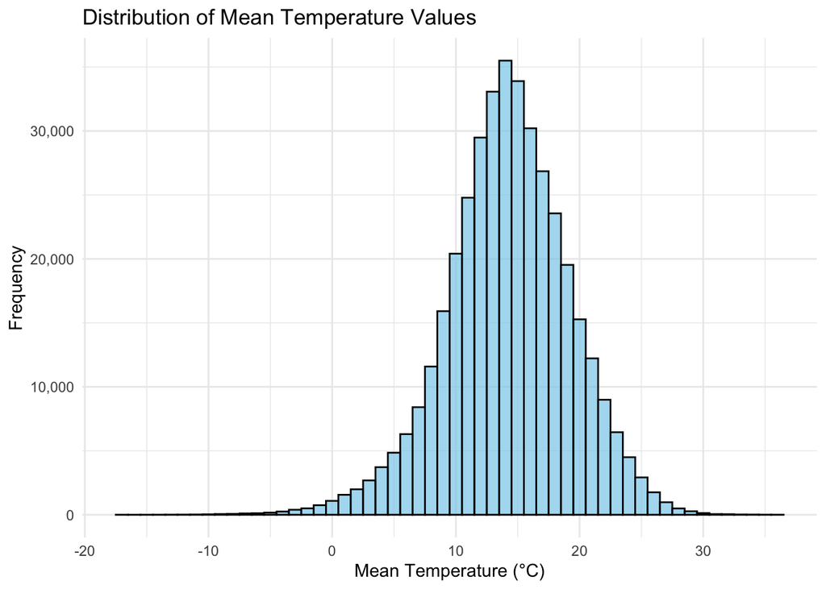

```r
# Plot histogram for mean_temp
ggplot(weather_peak %>%
         filter(!is.na(mean_temp)),
       aes(x = mean_temp)) +
  geom_histogram(binwidth = 1, fill = "skyblue", color = "black", alpha = 0.7) +
  labs(title = "Distribution of Mean Temperature Values",
       x = "Mean Temperature (°C)",
       y = "Frequency") +
  scale_y_continuous(labels = scales::comma) +
  theme_minimal()
```

*The distribution is approximately bell-shaped, normal distribution of mean temperature values.Most temperatures are centered around 10-15°C.*

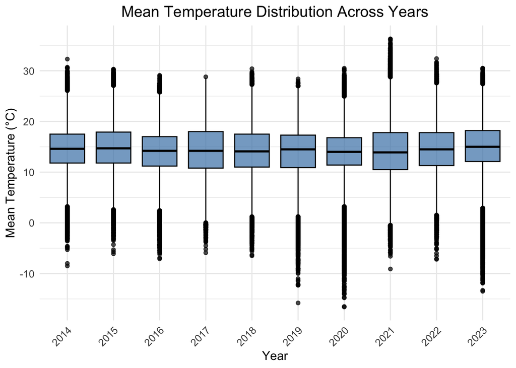

```r
# Plot boxplot for mean_temp
ggplot(weather_peak %>%
         filter(!is.na(mean_temp)),
       aes(x = factor(year), y = mean_temp)) +
  geom_boxplot(fill = "steelblue", color = "black", alpha = 0.7) +
  labs(title = "Mean Temperature Distribution Across Years",
       x = "Year",
       y = "Mean Temperature (°C)") +
  theme_minimal() +
  theme(plot.title = element_text(hjust = 0.5, size = 15),
        axis.title.x = element_text(size = 12),
        axis.title.y = element_text(size = 12),
        axis.text.x = element_text(size = 10, angle = 45, hjust = 1),
        axis.text.y = element_text(size = 10))
```

*The boxplot shows the distribution of mean temperature values with consistent temperature every year*

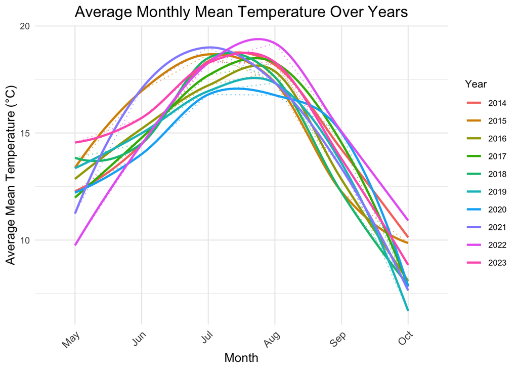

```r
# Line plot for mean_temp over time
ggplot(monthly_avg, aes(x = month, y = avg_temp, color = factor(year), group = year)) +
  geom_line(size = 0.5, alpha = 0.6, linetype = "dotted") +  # Raw data as dotted lines
  geom_smooth(se = FALSE, method = "loess", size = 1, linetype = "solid") +  # Smoothed trend line
  labs(title = "Average Monthly Mean Temperature Over Years",
       x = "Month",
       y = "Average Mean Temperature (°C)",
       color = "Year") +
  theme_minimal() +
  theme(axis.text.x = element_text(angle = 45, hjust = 1, size = 10),
        axis.title.x = element_text(size = 12),
        axis.title.y = element_text(size = 12),
        plot.title = element_text(size = 15, hjust = 0.5),
        legend.title = element_text(size = 10),
        legend.text = element_text(size = 8))
```

*The plot shows that the mean temperature generally peaks around July (07) and August (08) for most years.General pattern of temperature rise and fall is consistent across the years, similar seasonal temperature trends.*

#### Wind speed

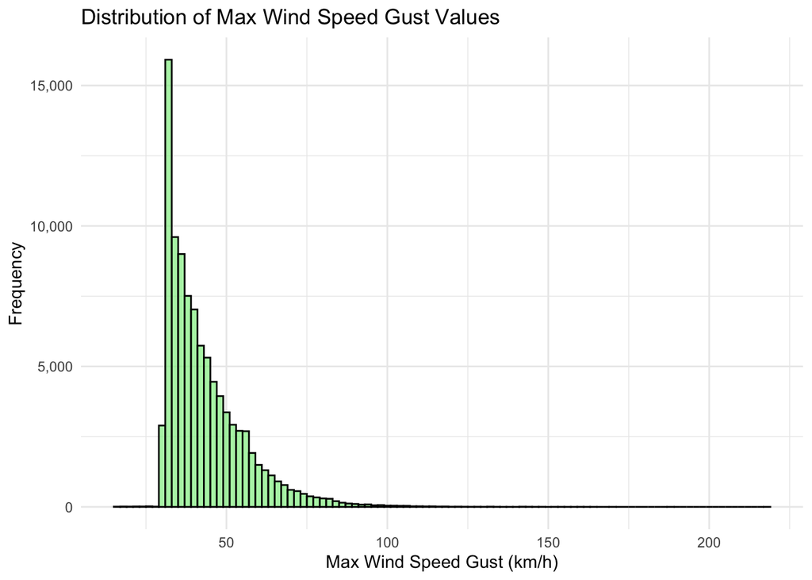

```r
# Plot histogram for spd_max_gust
ggplot(weather_peak %>%
         filter(!is.na(spd_max_gust)),
       aes(x = spd_max_gust)) +
  geom_histogram(binwidth = 2, fill = "lightgreen", color = "black", alpha = 0.7) + # The bin width is set to 2 km/h.
  labs(title = "Distribution of Max Wind Speed Gust Values",
       x = "Max Wind Speed Gust (km/h)",
       y = "Frequency") +
  scale_y_continuous(labels = scales::comma) +
  theme_minimal()
```

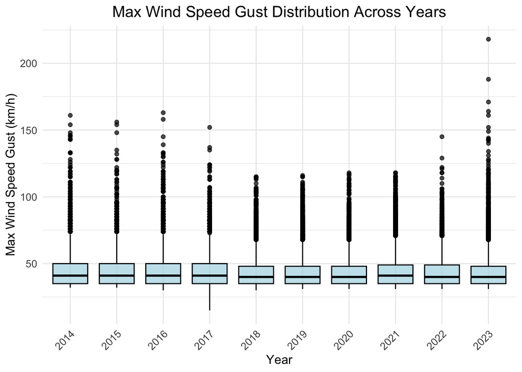

```r
# Plot boxplot for spd_max_gust
ggplot(weather_peak %>%
         filter(!is.na(spd_max_gust)),
       aes(x = factor(year), y = spd_max_gust)) +
  geom_boxplot(fill = "lightblue", color = "black", alpha = 0.7) +
  labs(title = "Max Wind Speed Gust Distribution Across Years",
       x = "Year",
       y = "Max Wind Speed Gust (km/h)") +
  theme_minimal() +
  theme(plot.title = element_text(hjust = 0.5, size = 15),
        axis.title.x = element_text(size = 12),
        axis.title.y = element_text(size = 12),
        axis.text.x = element_text(size = 10, angle = 45, hjust = 1),
        axis.text.y = element_text(size = 10))
```

*Despite some variations, the general pattern of wind speed is somewhat consistent across the years,indicating similar seasonal wind speed trends.*

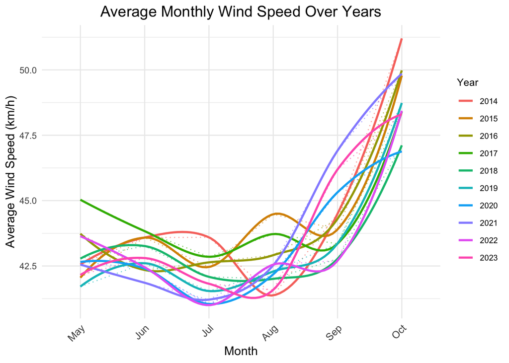

```r
# Line plot for avg_ws over time
ggplot(monthly_avg, aes(x = month, y = avg_ws, color = factor(year), group = year)) +
  geom_line(size = 0.5, alpha = 0.6, linetype = "dotted") +  # Raw data as dotted lines
  geom_smooth(se = FALSE, method = "loess", size = 1, linetype = "solid") +  # Smoothed trend line
  labs(title = "Average Monthly Wind Speed Over Years",
       x = "Month",
       y = "Average Wind Speed (km/h)",
       color = "Year") +
  theme_minimal() +
  theme(axis.text.x = element_text(angle = 45, hjust = 1, size = 10),
        axis.title.x = element_text(size = 12),
        axis.title.y = element_text(size = 12),
        plot.title = element_text(size = 15, hjust = 0.5),
        legend.title = element_text(size = 10),
        legend.text = element_text(size = 8))
```

The plot shows that wind speed generally increases from May to October for most years.  
Despite some variations, the pattern of wind speed rise and fall is consistent across the years,there are similar seasonal wind speed trends.

#### Precipitation

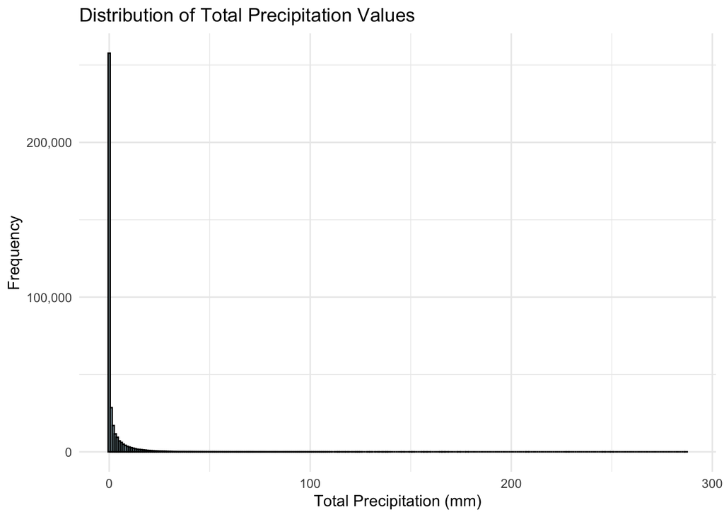

```r
# Plot histogram for total_precip
ggplot(weather_peak %>%
         filter(!is.na(total_precip)),
       aes(x = total_precip)) +
  geom_histogram(binwidth = 1, fill = "lightblue", color = "black", alpha = 0.7) +
  labs(title = "Distribution of Total Precipitation Values",
       x = "Total Precipitation (mm)",
       y = "Frequency") +
  scale_y_continuous(labels = scales::comma) +
  theme_minimal()
```

The histogram shows many days with little or no precipitation, mainly around zero.  
There are a few days with very high rainfall, as the distribution has a long tail to the right.

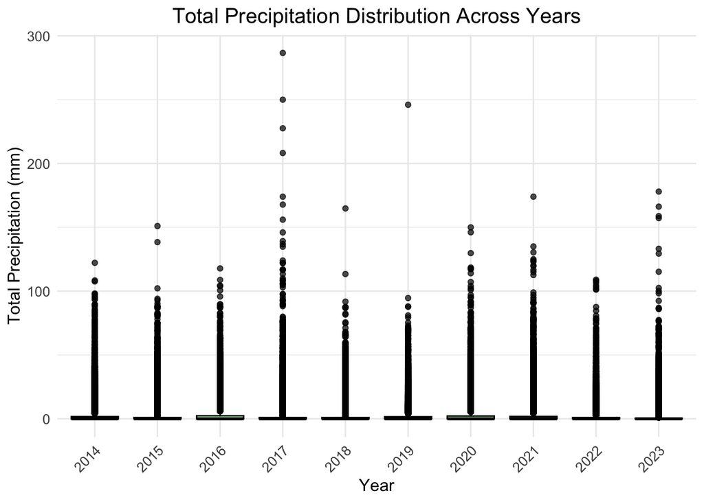

```r
# Plot boxplot for total_precip
ggplot(weather_peak %>%
         filter(!is.na(total_precip)),
       aes(x = factor(year), y = total_precip)) +
  geom_boxplot(fill = "lightgreen", color = "black", alpha = 0.7) +
  labs(title = "Total Precipitation Distribution Across Years",
       x = "Year",
       y = "Total Precipitation (mm)") +
  theme_minimal() +
  theme(plot.title = element_text(hjust = 0.5, size = 15),
        axis.title.x = element_text(size = 12),
        axis.title.y = element_text(size = 12),
        axis.text.x = element_text(size = 10, angle = 45, hjust = 1),
        axis.text.y = element_text(size = 10))
```

*Total precipitation is generally low with numerour outliers every year. In 2017, appears higher number of outliers compare to others and 2023 with slightly higher but still low in overall distribution.*

## Clear visualization of precipitation histogram

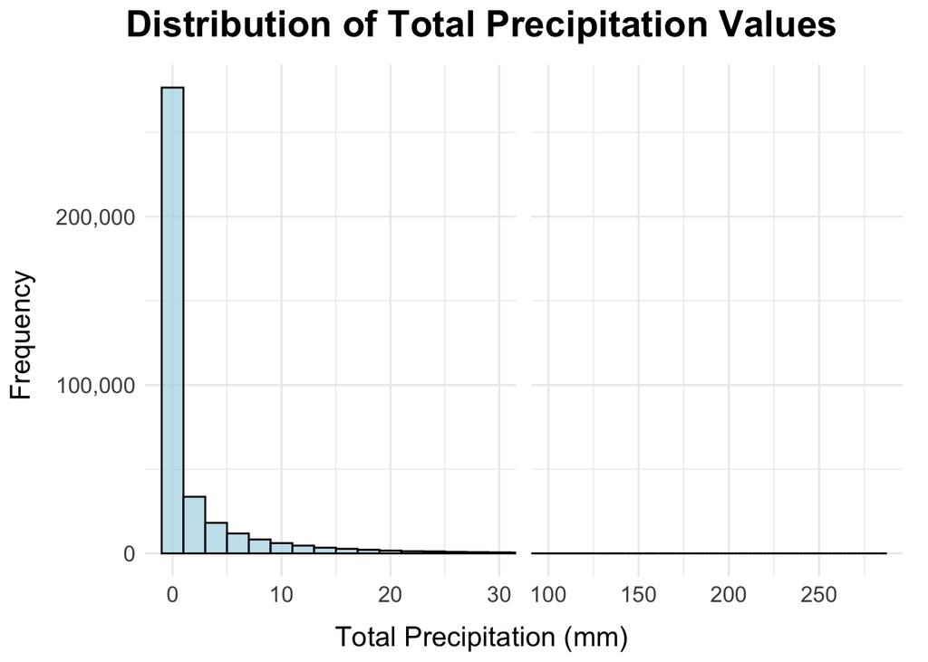

```r
# To create a cleared visualization and to see how the data can be cleaned,
# create the histogram plot with a gap using ggbreak

ggplot(weather_peak %>%
                      filter(!is.na(total_precip)),
                    aes(x = total_precip)) +
  geom_histogram(binwidth = 2, fill = "lightblue", color = "black", alpha = 0.7) +
  labs(title = "Distribution of Total Precipitation Values",
       x = "Total Precipitation (mm)",
       y = "Frequency") +
  scale_y_continuous(labels = scales::comma) +
  theme_minimal() +
  theme(
    plot.title = element_text(hjust = 0.5, size = 20, face = "bold"),
    axis.title.x = element_text(size = 15),
    axis.title.y = element_text(size = 15),
    axis.text.x = element_text(size = 12),
    axis.text.y = element_text(size = 12)
  ) +
  scale_x_break(c(30, 100), scales = 1) +
  theme(axis.ticks.y.right = element_blank(),
        axis.text.y.right = element_blank(),
        axis.title.y.right = element_blank())
```

*There are a few very high precipitation values (100 mm and above) that appear to be outliers. These extreme values could be significant weather events that impact the distribution, skewing the analysis.*

### Identify extreme values

```r
# Identify extreme values
extreme_values <- weather_peak %>%
  filter(total_precip > 200)

# Display extreme values
print(extreme_values)
```

```
## # A tibble: 5 × 12
##   station_name     station_id   lat   lon date        year month   day mean_temp
##   <chr>                 <dbl> <dbl> <dbl> <date>     <dbl> <ord> <dbl>     <dbl>
## 1 NITINAT RIVER H…        260  48.9 -125. 2017-10-16  2017 Oct      16       7.8
## 2 TAHSIS VILLAGE …        276  49.9 -127. 2017-10-16  2017 Oct      16      11.5
## 3 BOAT BLUFF              383  52.6 -129. 2017-09-10  2017 Sep      10      15
## 4 N VANC GROUSE M…        823  49.4 -123. 2019-09-17  2019 Sep      17       6
## 5 N VANCOUVER WHA…        833  49.3 -123. 2017-06-08  2017 Jun       8      NA
## # ℹ 3 more variables: spd_max_gust <dbl>, total_precip <dbl>, total_rain <dbl>
```

```r
# These values range from 208.2 mm to 286.6 mm.
# The dates of these extreme events are in the years 2017 and 2019.
# These high values likely correspond to significant weather events, such as heavy rainstorms.

# Identify heavy rains
rain_values <- weather_peak %>%
  filter(total_precip > 100)

# Count heavy rain events by year
heavy_rain_count <- rain_values %>%
  group_by(year) %>%
  summarise(count = n())

# Display the count of heavy rain events by year
print(heavy_rain_count)
```

```
## # A tibble: 10 × 2
##     year count
##    <dbl> <int>
##  1  2014     3
##  2  2015     3
##  3  2016     5
##  4  2017    25
##  5  2018     2
##  6  2019     1
##  7  2020    11
##  8  2021    11
##  9  2022     7
## 10  2023     8
```

*There are a total of 76 events in the overall 10 year dataset suggesting that the heavy rains occur few times a year.*

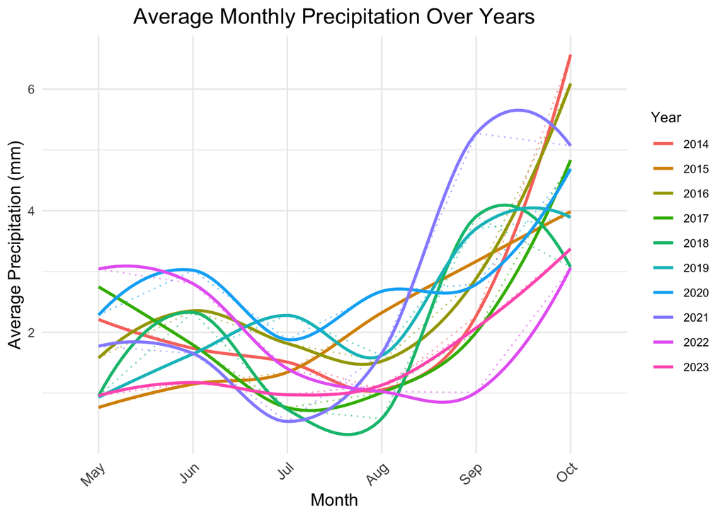

```r
# Line plot for avg_pcp over time
ggplot(monthly_avg, aes(x = month, y = avg_pcp, color = factor(year), group = year)) +
  geom_line(size = 0.5, alpha = 0.6, linetype = "dotted") +  # Raw data as dotted lines
  geom_smooth(se = FALSE, method = "loess", size = 1, linetype = "solid") +  # Smoothed trend line
  labs(title = "Average Monthly Precipitation Over Years",
       x = "Month",
       y = "Average Precipitation (mm)",
       color = "Year") +
  theme_minimal() +
  theme(axis.text.x = element_text(angle = 45, hjust = 1, size = 10),
        axis.title.x = element_text(size = 12),
        axis.title.y = element_text(size = 12),
        plot.title = element_text(size = 15, hjust = 0.5),
        legend.title = element_text(size = 10),
        legend.text = element_text(size = 8))
```

*Precipitation generally increases towards the end of the season,with peaks in September and October.*

#### END OF WEATHER EDA REPORT